# Multinomial and Generalized Linear Model Applications in Analyzing Premier League Forward Performance

Wayne Chilionje

2025-07-16

## Introduction

This report presents a range of statistical modelling techniques applied to football data, specifically focusing on player performance metrics from the 2023/24 Premier League season. The aim is to explore various models including multinomial logistic regression, Poisson regression, non-linear models, and fixed effects panel models using R. The analysis provides practical insights into how these models can be leveraged in performance analysis, talent identification, and strategic planning within football analytics. All this will be done using 23/24 Premier league shooting data, which is sourced from Fbref.

(https://fbref.com/en/comps/9/2023-2024/shooting/2023-2024-Premier-League-Stats)

## 1. Multinomial Logistic Regression: Classifying Forwards

We begin by using a multinomial logistic regression model to classify strikers into three tiers of forward ability: *Elite*, *Leading*, and *Good*. The classification is based on several shot-related metrics such as goals (Gls), shots (Sh), expected goals (xG), and other performance indicators.

#### Variable Descriptions:

- Player: The name of the football player.
- Age: The age of the player.
- 90s: The number of 90-minute periods the player has played, which can be seen as the player’s playing time in full matches.
- Gls: Goals scored by the player.
- Sh: Total number of shots taken by the player.
- SoT: Shots on target, indicating the number of shots that would have gone into the goal if not stopped by the goalkeeper.
- SoT%: The percentage of total shots that are on target.
- Sh/90: Average number of shots taken per 90 minutes.
- SoT/90: Average number of shots on target per 90 minutes.
- G/Sh: Goals per shot, indicating the player’s shooting efficiency.
- G/SoT: Goals per shot on target, indicating the player’s finishing ability.
- Dist: Average distance from the goal from where the shots are taken.
- PK: Penalty kicks scored by the player.
- PKatt: Penalty kick attempts made by the player.
- xG: Expected Goals, a metric that estimates the probability of a goal being scored based on the quality of the shots taken.
- npxG: Non-penalty expected goals, which excludes goals scored from penalty kicks.
- npxG/Sh: Non-penalty expected goals per shot.
- G-xG: The difference between actual goals scored and expected goals, indicating over- or underperformance.
- np:G-xG: The difference between non-penalty goals scored and non penalty expected goals.

### Data Preparation and Initial Exploration

We begin by loading the necessary libraries and the dataset, followed by a correlation analysis to explore relationships between variables and goals scored.

```r
library(readxl)
library(tidyr)
library(corrplot)
library(dplyr)
library(ggplot2)

PL_shooting <- read_excel("C:/Users/Admin/Downloads/23_24 PL Shooting Data.xlsx")
head(PL_shooting)
```

```
## # A tibble: 6 × 19
##   Player      Age `90s`   Gls    Sh   SoT `SoT%` `Sh/90` `SoT/90` `G/Sh` `G/SoT`
##   <chr>     <dbl> <dbl> <dbl> <dbl> <dbl>  <dbl>   <dbl>    <dbl>  <dbl>   <dbl>
## 1 Erling H…    23  28.4    27   113    50   44.2    3.99     1.76   0.18    0.4
## 2 Cole Pal…    21  29      22   100    37   37      3.45     1.28   0.13    0.35
## 3 Alexande…    23  25.1    21    72    36   50      2.87     1.44   0.22    0.44
## 4 Phil Fod…    23  31.7    19   105    48   45.7    3.31     1.51   0.18    0.4
## 5 Dominic …    25  36.9    19   106    35   33      2.87     0.95   0.16    0.49
## 6 Ollie Wa…    27  35.7    19   107    47   43.9    2.99     1.31   0.18    0.4
## # ℹ 8 more variables: Dist <dbl>, PK <dbl>, PKatt <dbl>, xG <dbl>, npxG <dbl>,
## #   `npxG/Sh` <dbl>, `G-xG` <dbl>, `np:G-xG` <dbl>
```

```r
str(PL_shooting) # Structure of data
```

```
## tibble [60 × 19] (S3: tbl_df/tbl/data.frame)
##  $ Player : chr [1:60] "Erling Haaland" "Cole Palmer" "Alexander Isak" "Phil Foden" ...
##  $ Age    : num [1:60] 23 21 23 23 25 27 31 31 26 26 ...
##  $ 90s    : num [1:60] 28.4 29 25.1 31.7 36.9 35.7 28.2 32.6 33.5 25.4 ...
##  $ Gls    : num [1:60] 27 22 21 19 19 19 18 17 16 16 ...
##  $ Sh     : num [1:60] 113 100 72 105 106 107 107 83 84 44 ...
##  $ SoT    : num [1:60] 50 37 36 48 35 47 47 38 37 25 ...
##  $ SoT%   : num [1:60] 44.2 37 50 45.7 33 43.9 43.9 45.8 44 56.8 ...
##  $ Sh/90  : num [1:60] 3.99 3.45 2.87 3.31 2.87 2.99 3.8 2.55 2.5 1.74 ...
##  $ SoT/90 : num [1:60] 1.76 1.28 1.44 1.51 0.95 1.31 1.67 1.17 1.1 0.99 ...
##  $ G/Sh   : num [1:60] 0.18 0.13 0.22 0.18 0.16 0.18 0.12 0.18 0.19 0.32 ...
##  $ G/SoT  : num [1:60] 0.4 0.35 0.44 0.4 0.49 0.4 0.28 0.39 0.43 0.56 ...
##  $ Dist   : num [1:60] 11.9 22.1 14.5 18.5 12.2 12.8 15.5 15.5 14.2 12.7 ...
##  $ PK     : num [1:60] 7 9 5 0 2 0 5 2 0 2 ...
##  $ PKatt  : num [1:60] 8 9 6 0 3 0 7 2 0 2 ...
##  $ xG     : num [1:60] 29.2 18.2 20.3 10.3 19.6 16.8 21.2 12 11.6 10.9 ...
##  $ npxG   : num [1:60] 22.9 11.1 15.6 10.3 17.2 16.8 15.5 10.4 11.6 9.4 ...
##  $ npxG/Sh: num [1:60] 0.2 0.11 0.22 0.1 0.16 0.16 0.15 0.13 0.14 0.21 ...
##  $ G-xG   : num [1:60] -2.2 3.8 0.7 8.7 -0.6 2.2 -3.2 5 4.4 5.1 ...
##  $ np:G-xG: num [1:60] -2.9 1.9 0.4 8.7 -0.2 2.2 -2.5 4.6 4.4 4.6 ...
```

Now we conduct exploratory data analysis to understand the relationships among variables.

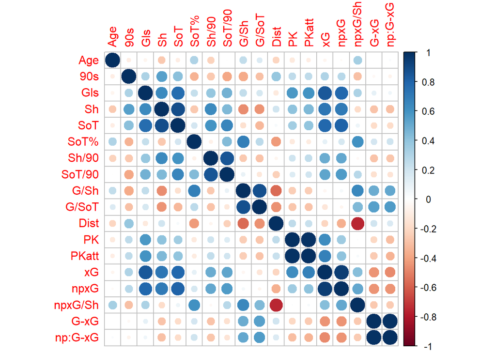

```r
# Select numeric columns (for correlation analysis)
library(lares)
numerical_vars1 <- sapply(PL_shooting, is.numeric)
numeric_data1 <- PL_shooting[, numerical_vars1]
correlation_matrix1 <- cor(numeric_data1)
corrplot(correlation_matrix1)
```

```r
corr_cross(PL_shooting, max_pvalue = 0.05, top = 15, grid = TRUE)
```

```
## Returning only the top 15. You may override with the 'top' argument
```

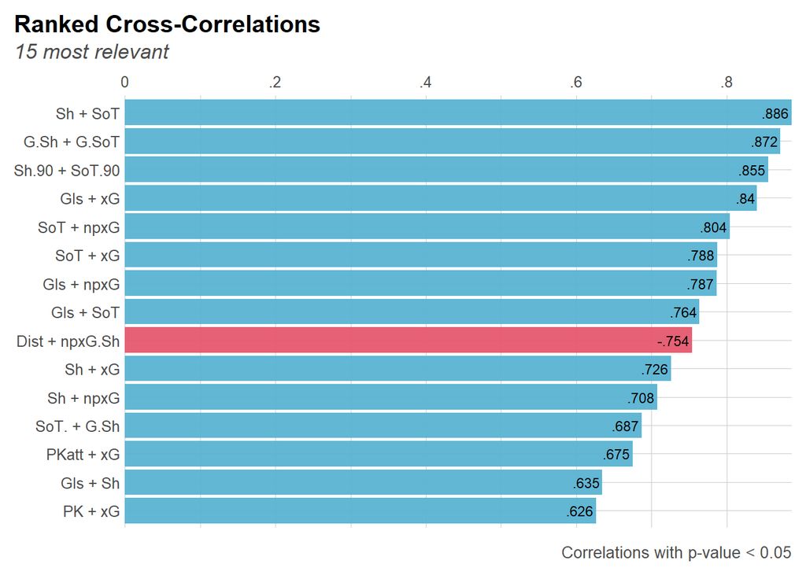

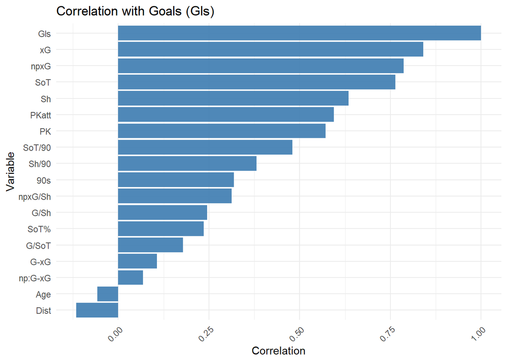

```r
### Correlation with goals
# Calculate correlations between each numeric variable and GF
cor_with_GF <- sapply(numeric_data1,
 function(x) cor(x, PL_shooting$Gls,
 use = "complete.obs"))
# Convert the results to a data frame
cor_with_GF_df <- data.frame(
 Variable = names(cor_with_GF),
 Correlation = cor_with_GF
)
# Sort the data frame by the absolute value of correlation in descending order
cor_with_GF_df <- cor_with_GF_df %>%
 arrange(desc(abs(Correlation)))
# Create a bar plot
ggplot(cor_with_GF_df, aes(x = reorder(Variable, Correlation), y = Correlation)) +
 geom_bar(stat = "identity", fill = "steelblue") +
 coord_flip() + # Flip coordinates for better readability
 labs(title = "Correlation with Goals (Gls)", x = "Variable", y = "Correlation") +
 theme_minimal() +
 theme(axis.text.x = element_text(angle = 45, hjust = 1))
```

#### Key Insights

**Correlation with Goals (Gls) Plot:**

1. **High Correlation with xG and npxG**: Goals (Gls) have a very high correlation with expected goals (xG) and non-penalty expected goals (npxG). This suggests that these metrics are strong predictors of actual goals scored.
2. **Positive Correlation with SoT and Sh**: Shots on target (SoT) and total shots (Sh) also show a strong positive correlation with goals, indicating that more attempts lead to more goals.
3. **Moderate Correlation with PK and PKatt**: Penalty kicks (PK) and penalty kick attempts (PKatt) have a moderate positive correlation with goals, reflecting the importance of penalties in goal scoring.
4. **Low Correlation with Age and Distance**: Age and average shot distance (Dist) have a very low correlation with goals, suggesting they are less significant predictors in this context.

**Ranked Cross-Correlations Plot**

### Model Fitting (Multinormial Regression)

The multinomial logistic regression model is used to classify players into Leading, Elite, and Good categories based on performance metrics. The exact code for assigning labels and fitting the model is not fully visible in the PDF, but we can infer the approach based on the context.

```r
# Assigning labels of Forward ability based on some criteria
PL_shooting <- PL_shooting %>%
 mutate(
 Forward_Ability = case_when(
 Gls >= 15 ~ "Elite",
 Gls >= 10 & Gls < 15 ~ "Leading",
 TRUE ~ "Good"
 )
 )
# Convert Forward_Ability to a factor
PL_shooting$Forward_Ability <- factor(PL_shooting$Forward_Ability,
 levels = c("Good", "Leading", "Elite"))
# Fit the multinomial logistic regression model
library(nnet)
mult_model <- multinom(Forward_Ability ~ Age + `90s` + Gls + Sh + SoT + `Sh/90` + `SoT/90` +
Dist + xG, data = PL_shooting)
summary(mult_model)
```

```
## Call:
## multinom(formula = Forward_Ability ~ Age + `90s` + Gls + Sh +
##     SoT + `Sh/90` + `SoT/90` + Dist + xG, data = PL_shooting)
##
## Coefficients:
##         (Intercept)      Age      `90s`      Gls       Sh       SoT    `Sh/90`
## Leading   -54.38091 1.680883  -8.448263 29.08111 3.168505 0.1652801  -52.12325
## Elite     -51.04008 2.234458 -16.483854 45.31878 6.427392 0.3499954 -135.59130
##          `SoT/90`       Dist         xG
## Leading -36.64066 -1.5526650  -6.273258
## Elite   -52.13658 -0.9290217 -10.533119
##
## Std. Errors:
##         (Intercept)       Age     `90s`      Gls        Sh       SoT   `Sh/90`
## Leading  2225.06839  212.0388  264.1674 606.8037  209.2325  353.9386 4373.8613
## Elite      98.10357 3543.9342 4457.3546 952.7811 2165.6343 5013.4574  634.6647
##          `SoT/90`      Dist        xG
## Leading 8409.3783  118.0515  211.1648
## Elite    171.1755 1025.4356 1757.7203
##
## Residual Deviance: 0.000114774
## AIC: 40.00011
```

#### Key Insights

Less Significant Predictors

- Variables such as **Age**, **90s**, **Sh**, **SoT**, **Sh/90**, **SoT/90**, and **Dist** have mixed effects and vary in significance.

**Model Fit**

#### Implications

**Player Classification**

- The model effectively classifies players into performance tiers based on goal-scoring ability using multiple performance metrics.

**Understanding Player Performance**

- By analyzing the coefficients, teams can:
  - Identify key development areas such as improving shot accuracy.
  - Encourage players to increase goal-scoring opportunities through higher attempt volume.

#### Practical Implications

The multinomial regression model categorizes players into three levels of forward ability: **Leading**, **Elite**, and **Good**. This offers several practical benefits:

**1. Player Evaluation and Recruitment**

- **Talent Identification:**  
  The model helps in identifying key metrics that differentiate between *Good*, *Leading*, and *Elite* forwards. Clubs can focus on these metrics during scouting and recruitment to identify potential top-performing players.
- **Performance Benchmarking:**  
  By understanding which metrics are most predictive of higher goal-scoring ability, teams can set performance benchmarks for players at different ability levels.

**2. Training and Development**

- **Targeted Training Programs:**  
  Coaches can develop focused training programs to improve specific skills that the model identifies as crucial for advancement (e.g., from *Good* to *Elite*). For instance, improving **Shot Accuracy (SoT)** or **Expected Goals (xG)**.
- **Performance Tracking:**  
  The model offers a framework for tracking player performance over time, enabling coaches to monitor development in key performance areas.

**3. Strategic Planning and Game Tactics**

- **Game Strategy:**  
  Understanding the strengths of *Leading* and *Elite* forwards can inform tactical decisions. Teams can position players in ways that maximize their scoring potential based on predicted ability.
- **Opponent Analysis:**  
  Similar models can be used to assess opposing forwards, assisting in the development of defensive strategies to counter high-performing opponents.

**4. Resource Allocation**

- **Financial Decisions:**  
  Clubs can make more informed decisions on player acquisitions and contract renewals by evaluating players’ categorical ability levels.
- **Resource Optimization:**  
  Training resources, coaching staff, and analytical tools can be allocated more efficiently to nurture players with potential to reach *Elite* status.

## 2. Poisson Regression for Goals Scored

We use Poisson regression to model the number of goals scored (Gls) as a function of various predictors. Poisson regression is suitable for count data, such as goals scored.

### Model Specification

The Poisson regression model is specified with goals as the response variable and predictors including Age, 90s, Sh, SoT, SoT%, Sh/90, SoT/90, Dist, PK, PKatt, xG, and npxG.

Here’s how the model is applied:

- Formula: The model is specified with goals as the response variable and predictors including Age, 90s, Sh, SoT, SoT% , Sh/90 , SoT/90 , Dist, PK, PKatt, xG, and npxG.
- Family: The Poisson family is used in the glm function, indicating that the response variable follows a Poisson distribution.

```r
# Fit Poisson regression model
poisson_model <- glm(Gls ~ Age + `90s` + Sh + SoT + `SoT%` + `Sh/90` + `SoT/90` + Dist + PK +
PKatt + xG + npxG, family = poisson, data = PL_shooting)
summary(poisson_model)
```

```
##
## Call:
## glm(formula = Gls ~ Age + `90s` + Sh + SoT + `SoT%` + `Sh/90` +
##     `SoT/90` + Dist + PK + PKatt + xG + npxG, family = poisson,
##     data = PL_shooting)
##
## Coefficients:
##               Estimate Std. Error z value Pr(>|z|)
## (Intercept)  1.0844498  1.7980865   0.603    0.546
## Age         -0.0005165  0.0154023  -0.034    0.973
## `90s`        0.0096018  0.0287693   0.334    0.739
## Sh          -0.0061780  0.0162187  -0.381    0.703
## SoT          0.0269353  0.0349476   0.771    0.441
## `SoT%`       0.0131327  0.0271697   0.483    0.629
## `Sh/90`      0.2091339  0.6069558   0.345    0.730
## `SoT/90`    -0.4539992  1.2618371  -0.360    0.719
## Dist        -0.0108308  0.0225834  -0.480    0.632
## PK           0.2032036  0.1449200   1.402    0.161
## PKatt       -0.4439175  1.0054641  -0.442    0.659
## xG           0.3912076  1.1778675   0.332    0.740
## npxG        -0.3655595  1.1750512  -0.311    0.756
##
## (Dispersion parameter for poisson family taken to be 1)
##
##     Null deviance: 102.619  on 59  degrees of freedom
## Residual deviance:  21.952  on 47  degrees of freedom
## AIC: 297.79
##
## Number of Fisher Scoring iterations: 4
```

```r
# Assumptions and diagnostics
# Check for overdispersion
dispersion_test <- sum(residuals(poisson_model,
 type = "pearson")^2) / df.residual(poisson_model)
print(dispersion_test)
```

```
## [1] 0.4689936
```

```r
library(lmtest)
dwtest(poisson_model)
```

```
##
##  Durbin-Watson test
##
## data:  poisson_model
## DW = 1.2446, p-value = 0.0009114
## alternative hypothesis: true autocorrelation is greater than 0
```

## 3. Polynomial Regression for Non-Linear Relationships

### Theoretical Basis

Polynomial regression is a type of non-linear regression where the relationship between the independent variable (e.g., Age) and the dependent variable (e.g., Goals) is modeled as an nth-degree polynomial. The model takes the form:

$$y = \beta_0 + \beta_1 x + \beta_2 x^2 + \dots + \beta_n x^n +
\varepsilon$$

Where:

- $y$ is the **dependent variable** (*Goals*),
- $x$ is the **independent variable** (*Age*),
- $\beta_0, \beta_1, \dots, \beta_n$ are the **coefficients**,
- $\varepsilon$ is the **error term**.

We apply polynomial regression to model the non-linear relationship between Age and Goals scored.

#### 3.2 Advantages and Limitations

**Advantages**

- **Flexibility:**  
  Polynomial regression can model more complex relationships compared to simple linear regression.
- **Good for Non-linear Trends:**  
  It is especially useful when the data shows a curvilinear relationship.

**Limitations**

- **Overfitting:**  
  High-degree polynomial models may capture noise in the data, leading to overfitting.
- **Interpretation:**  
  Coefficients of higher-degree terms can be difficult to interpret and may not have intuitive meaning.
- **Extrapolation:**  
  Predictions outside the observed data range can be highly unreliable and unstable.

#### 3.3 Selecting Data and Fitting the Model

We will use the same **shooting dataset** from Questions 1 and 2.  
- **Response Variable:** `Goals`  
- **Predictor Variable:** `Age`

A polynomial regression model will be fitted to explore the relationship between age and goal-scoring ability.

```r
# Polynomial regression model
poly_model <- lm(Gls ~ poly(Age, 2, raw=TRUE),
 data=PL_shooting)
summary(poly_model)
```

```
##
## Call:
## lm(formula = Gls ~ poly(Age, 2, raw = TRUE), data = PL_shooting)
##
## Residuals:
##    Min     1Q Median     3Q    Max
## -5.189 -3.295 -1.307  1.351 15.986
##
## Coefficients:
##                             Estimate Std. Error t value Pr(>|t|)
## (Intercept)               13.1777662 33.1811302   0.397    0.693
## poly(Age, 2, raw = TRUE)1 -0.1010605  2.5747255  -0.039    0.969
## poly(Age, 2, raw = TRUE)2  0.0003027  0.0494576   0.006    0.995
##
## Residual standard error: 4.679 on 57 degrees of freedom
## Multiple R-squared:  0.003329,   Adjusted R-squared:  -0.03164
## F-statistic: 0.09518 on 2 and 57 DF,  p-value: 0.9094
```

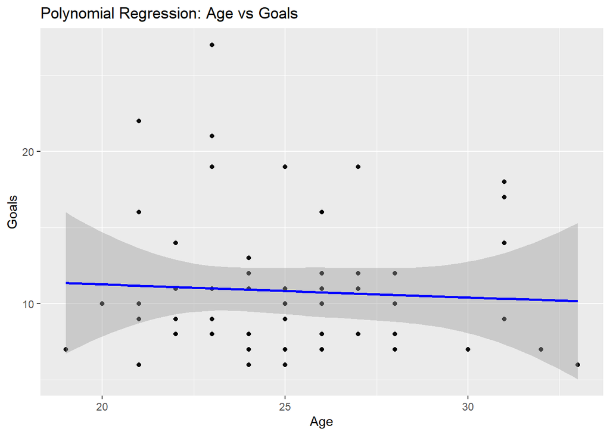

```r
# Plot the data and the model
ggplot(PL_shooting, aes(x=Age, y=Gls)) +
 geom_point() +
 stat_smooth(method="lm",
 formula=y~poly(x, 2, raw=TRUE),
 col="blue") +
 labs(title="Polynomial Regression: Age vs Goals",
 x="Age", y="Goals")
```

#### Summary of the Results

**1. Model and Coefficients**

- The regression model uses **Age** as the predictor and **Goals** as the outcome variable.
- A **polynomial regression of degree 2** is fitted.
- Estimated coefficients:
  - **Intercept:** 13.18
  - **Age (linear term):** -0.10
  - **Age² (quadratic term):** 0.0003

**2. Statistical Significance**

- None of the coefficients are statistically significant.
- **P-values:**
  - Age (linear): 0.969
  - Age² (quadratic): 0.995
- This indicates that **Age**, in both its linear and quadratic forms, does **not** have a significant impact on the number of goals scored.

**3. Model Fit**

- **R-squared:** 0.0033  
  The model explains only **0.33%** of the variability in goals scored.
- **F-statistic:** 0.09518
  - **P-value:** 0.9094
  - Indicates that the model is **not a good fit** for the data.

**4. Residuals**

- The residuals show a **wide range**, highlighting variability in the data that the model does not explain.

#### Insights from the Plot

**1. Visualization**

- The scatter plot displays the relationship between **Age** and **Goals**, with the polynomial regression line overlaid.
- The regression line appears **almost flat**, reinforcing the conclusion that there is **no strong relationship** between age and goals.

**2. Distribution of Goals**

- Goal counts are **spread across a wide range of ages**, with **no clear pattern or trend**.

#### Conclusion

- The analysis indicates **no significant non-linear relationship** between a player’s **age** and the **number of goals scored**.
- The model explains very **little of the variance**, suggesting that **other variables**, not included in the model, may be more relevant predictors of goal-scoring performance.

### Question 4: Fixed Effects Panel Data Model

#### Theoretical Basis

Panel data models analyze data involving multiple entities (e.g individuals, companies, countries) observed over multiple periods. The fixed effects model controls for time-invariant characteristics, allowing consistent estimation of time-varying variables’ effects. The model takes the form:

$$y_{it} = \alpha_i + \beta X_{it} + \varepsilon_{it}$$

Where:

- $y_{it}$: **Dependent variable** (*Performance*) for entity $i$ at time $t$
- $\alpha_i$: **Entity-specific intercept** (fixed effect)
- $X_{it}$: **Vector of independent variables**
- $\beta$: **Vector of coefficients**
- $\varepsilon_{it}$: **Error term**

#### Assumptions

- **Entity-specific characteristics are constant over time:**  
  Any unobserved characteristics that differ between entities but remain constant over time are captured by the fixed effects.
- **No perfect multicollinearity:**  
  The independent variables should not be perfectly collinear.
- **Error terms are uncorrelated with the independent variables:**  
  This ensures that the coefficient estimates are unbiased.

#### Methodology

1. **Data Structure:**  
   Convert the dataset into **panel data format**, clearly specifying the entity (e.g., player or team) and time period.
2. **Model Estimation:**  
   Use the **fixed effects (within) estimator**, which involves demeaning the data to remove entity-specific effects.
3. **Hypothesis Testing:**  
   Conduct statistical tests on the coefficients to assess their **significance**.

#### Generating Data

We will create **synthetic panel data** to demonstrate the application of the fixed effects model.

```r
# Generate synthetic data
set.seed(333)
Club <- rep(c("Pescara", "Assisi", "Rome", "Lucca"), each = 5)
Season <- rep(1:5, times = 4)
Performance <- round(rnorm(20, 70, 5))
synthetic_data <- data.frame(Club, Season, Performance)
synthetic_data
```

```
##       Club Season Performance
## 1  Pescara      1          70
## 2  Pescara      2          80
## 3  Pescara      3          60
## 4  Pescara      4          71
## 5  Pescara      5          62
## 6   Assisi      1          69
## 7   Assisi      2          76
## 8   Assisi      3          73
## 9   Assisi      4          72
## 10  Assisi      5          67
## 11    Rome      1          64
## 12    Rome      2          66
## 13    Rome      3          70
## 14    Rome      4          67
## 15    Rome      5          66
## 16   Lucca      1          71
## 17   Lucca      2          72
## 18   Lucca      3          70
## 19   Lucca      4          77
## 20   Lucca      5          68
```

#### Model Fitting

We fit a fixed effects model using the plm package, with Performance as the dependent variable and Season as the predictor.

```r
library(plm)
fixed_effects_model <- plm(Performance ~ Season, data = synthetic_data,
                           index = c("Club", "Season"), model = "within")
summary(fixed_effects_model)
```

```
## Oneway (individual) effect Within Model
##
## Call:
## plm(formula = Performance ~ Season, data = synthetic_data, model = "within",
##     index = c("Club", "Season"))
##
## Balanced Panel: n = 4, T = 5, N = 20
##
## Residuals:
##    Min. 1st Qu.  Median 3rd Qu.    Max.
## -7.3000 -1.6500 -0.0500  2.5625  7.4500
##
## Coefficients:
##         Estimate Std. Error t-value Pr(>|t|)
## Season2   5.0000     3.0145  1.6586   0.1231
## Season3  -0.2500     3.0145 -0.0829   0.9353
## Season4   3.2500     3.0145  1.0781   0.3022
## Season5  -2.7500     3.0145 -0.9122   0.3796
##
## Total Sum of Squares:    368.8
## Residual Sum of Squares: 218.1
## R-Squared:      0.40862
## Adj. R-Squared: 0.063652
## F-statistic: 2.0729 on 4 and 12 DF, p-value: 0.14765
```

### Summary of the Results

#### 1. Model and Coefficients

The fixed effects model uses **Performance** as the outcome variable and **Seasons** as the predictor.

Estimated coefficients for each season: